# Module 4.1 - Interoperability Standards - WMS, KML, and XML

## OGC Web map Services - WMS

## WMS - Overview

- Open Geospatial Consortium standard for requesting
  - Service Metadata (`GetCapabilities`) - an XML file representing information about a specific WMS service and its component layers
  - Map Images (`GetMap`) - graphic files representing one or more layers from a single WMS service for a specified area of interest, and, optionally, for a specified point in time
  - Feature Information (`GetFeatureInfo`) - a basic representation (in a variety of formats) of the attributes associated with a specific pixel location in a map image
- A WMS will return to the requesting system one of the above products OR an error message (in XML by default)
- Related [Style Layer Descriptor](http://www.opengeospatial.org/standards/sld) standard supports dynamic updating of visualization options
- [OGC WMS Documentation Access Page](http://www.opengeospatial.org/standards/wms)

### WMS *GetCapabilities* Request

| Request Parameter | 1.0 | 1.1 | 1.1.1 | 1.3.0 | Description |
| --- | --- | --- | --- | --- | --- |
| WMTVER=1.0.0 | R |  |  |  | Request version |
| VERSION=version |  | O | O | O | Request version |
| SERVICE=WMS | R | R | R | R | Service type |
| REQUEST=capabilities | R |  |  |  | Request name |
| REQUEST=GetCapabilities |  | R | R | R | Request name |
| UPDATESEQUENCE=string |  | O | O | O | Sequence number or string for cache control |
| Vendor-specific parameters | O |  |  |  | Vendor-specific parameters |

R=Required / O=Optional

### WMS *GetMap* Request (Core)

| Request Parameter | 1.0 | 1.1 | 1.1.1 | 1.3.0 | Description |
| --- | --- | --- | --- | --- | --- |
| WMTVER=1.0.0 | R |  |  |  | Request version |
| VERSION=version |  | R | R | R | Request version. |
| REQUEST=map | R |  |  |  | Request name. |
| REQUEST=GetMap |  | R | R | R | Request name. |
| LAYERS=layer_list | R | R | R | R | Comma-separated list of one or more map |
|  |  |  |  |  | layers. Optional (ver. 1.1, 1.1.1) if SLD |
|  |  |  |  |  | parameter is present. |
| STYLES=style_list | R | R | R | R | Comma-separated list of one rendering style |
|  |  |  |  |  | per requested layer. Optional if SLD |
|  |  |  |  |  | parameter is present. |
| SRS=namespace:identifier | R | R | R |  | Spatial Reference System. |
| CRS=namespace:identifier |  |  |  | R | Spatial Reference System. |
| BBOX=minx,miny,maxx,maxy | R | R | R | R | Bounding box corners (lower left, upper right) |
|  |  |  |  |  | in SRS units. |
| WIDTH=output_width | R | R | R | R | Width in pixels of map picture. |

### WMS GetMap Request (Core) - cont.

| Request Parameter | 1.0 | 1.1 | 1.1.1 | 1.3.0 | Description |
| --- | --- | --- | --- | --- | --- |
| HEIGHT=output_height | R | R | R | R | Height in pixels of map picture. |
| FORMAT=output_format | R | R | R | R | Output format of map. |
| TRANSPARENT=TRUE or FALSE | O | O | O | O | Background transparency of map (default=FALSE). |
| BGCOLOR=color_value | O | O | O | O | Hexadecimal red-green-blue color value for the |
|  |  |  |  |  | background color (default=0xFFFFFF). |
| EXCEPTIONS=exception_format | O | O | O | O | The format in which exceptions are to be reported |
|  |  |  |  |  | by the WMS (default=XML). |
| TIME=time |  | O | O | O | Time value of layer desired. |
| ELEVATION=elevation |  | O | O | O | Elevation of layer desired. |
| Other sample dimensions |  | O | O | O | Values of other dimensions as appropriate. |
| Vendor specific parameters | O | O | O | O | Vendor specific parameters |

### WMS GetFeatureInfo Request

| Request Parameter | 1.0 | 1.1 | 1.1.1 | 1.3.0 | Description |
| --- | --- | --- | --- | --- | --- |
| WMTVER=1.0.0 | R |  |  |  | Request version. |
| VERSION=version |  | R | R | R | Request version. |
| REQUEST=feature_info | R |  |  |  | Request name. |
| REQUEST=GetFeatureInfo |  | R | R | R | Request name. |
| `<map_request_copy>` | R | R | R | R | Partial copy of the Map request parameters that |
|  |  |  |  |  | generated the map for which information is desired |
| QUERY_LAYERS=layer_list | R | R | R | R | Comma-separated list of one or more layers |
|  |  |  |  |  | to be queried. |
| INFO_FORMAT=output_format | O | O | O | R | Return format of feature information (MIME type). |
| FEATURE_COUNT=number | O | O | O | O | Number of features about which to return |
|  |  |  |  |  | information (default=1). |

### WMS GetFeatureInfo Request - cont.

| Request Parameter | 1.0 | 1.1 | 1.1.1 | 1.3.0 | Description |
| --- | --- | --- | --- | --- | --- |
| X=pixel_column | R | R | R |  | X coordinate in pixels of feature |
|  |  |  |  |  | (measured from upper left corner=0) |
| I=pixel_column |  |  |  | R | i coordinate in pixels of feature in Map CS |
| Y=pixel_row | R | R | R |  | Y coordinate in pixels of feature |
|  |  |  |  |  | (measured from upper left corner=0) |
| J=pixel_row |  |  |  | R | j coordinate in pixels of feature in Map CS |
| EXCEPTIONS=exception_format |  | O | O | O | The format in which exceptions are to be |
|  |  |  |  |  | reported by the WMS (default=XML). |
| Vendor-specific parameters | O | O | O |  | Optional experimental parameters. |

### WMS Sample Requests - GetCapabilities

```xml
http://gstore.unm.edu/apps/rgis/datasets/6ca5428a-a78c-4c82-8120-da70dc92f2cc/services/ogc/wms?
    SERVICE=wms&
    REQUEST=GetCapabilities&
    VERSION=1.1.1
```

[Live Link](http://gstore.unm.edu/apps/rgis/datasets/6ca5428a-a78c-4c82-8120-da70dc92f2cc/services/ogc/wms?SERVICE=wms&REQUEST=GetCapabilities&VERSION=1.1.1)

```xml
<?xml version='1.0' encoding="ISO-8859-1" standalone="no" ?>
<!DOCTYPE WMT_MS_Capabilities SYSTEM "http://schemas.opengis.net/wms/1.1.1/
WMS_MS_Capabilities.dtd"
 [
 <!ELEMENT VendorSpecificCapabilities EMPTY>
 ]>  <!-- end of DOCTYPE declaration -->

<WMT_MS_Capabilities version="1.1.1">

<!-- MapServer version 6.0.3 OUTPUT=GIF OUTPUT=PNG OUTPUT=JPEG OUTPUT=KML SUPPORTS=PROJ
SUPPORTS=AGG SUPPORTS=FREETYPE SUPPORTS=ICONV SUPPORTS=WMS_SERVER SUPPORTS=WMS_CLIENT
SUPPORTS=WFS_SERVER SUPPORTS=WFS_CLIENT SUPPORTS=WCS_SERVER SUPPORTS=SOS_SERVER
INPUT=POSTGIS INPUT=OGR INPUT=GDAL INPUT=SHAPEFILE -->

<Service>
  <Name>OGC:WMS</Name>
  <Title>rgis Dataset (6ca5428a-a78c-4c82-8120-da70dc92f2cc)</Title>
  <Abstract>WMS Service for rgis dataset State Boundary - 2010</Abstract>
        <KeywordList>
          <Keyword>rgis</Keyword>
          <Keyword> New Mexico</Keyword>
        </KeywordList>
  <OnlineResource xmlns:xlink="http://www.w3.org/1999/xlink" xlink:href="http://
  gstore.unm.edu/apps/rgis/datasets/6ca5428a-a78c-4c82-8120-da70dc92f2cc/services/ogc/wms"/>
  <ContactInformation>
    <ContactPersonPrimary>
      <ContactPerson>GStore Support</ContactPerson>
      <ContactOrganization>Earth Data Analysis Center</ContactOrganization>
    </ContactPersonPrimary>
      <ContactPosition>technical support</ContactPosition>
    <ContactAddress>
        <AddressType>Mailing address</AddressType>
        <Address>Earth Data Analysis Center, MSC01 1110, 1 University of New Mexico</Address>
        <City>Albuquerque</City>
        <StateOrProvince>NM</StateOrProvince>
        <PostCode>87131</PostCode>
        <Country>US</Country>
    </ContactAddress>
      <ContactVoiceTelephone>(505) 277-3622</ContactVoiceTelephone>
      <ContactFacsimileTelephone>(505) 277-3614</ContactFacsimileTelephone>
  <ContactElectronicMailAddress>devteam@edac.unm.edu</ContactElectronicMailAddress>
  </ContactInformation>
  <Fees>None</Fees>
  <AccessConstraints>none</AccessConstraints>
</Service>

<Capability>
  <Request>
    <GetCapabilities>
      <Format>application/vnd.ogc.wms_xml</Format>
      <DCPType>
        <HTTP>
          <Get><OnlineResource xmlns:xlink="http://www.w3.org/1999/xlink" xlink:href=
          "http://gstore.unm.edu/apps/rgis/datasets/6ca5428a-a78c-4c82-8120-da70dc92f2cc/
          services/ogc/wms?"/></Get>
          <Post><OnlineResource xmlns:xlink="http://www.w3.org/1999/xlink" xlink:href=
          "http://gstore.unm.edu/apps/rgis/datasets/6ca5428a-a78c-4c82-8120-da70dc92f2cc/
          services/ogc/wms?"/></Post>
        </HTTP>
      </DCPType>
    </GetCapabilities>
    <GetMap>
      <Format>image/png</Format>
      <Format>image/gif</Format>
      <Format>image/jpeg</Format>
      <Format>image/png; mode=8bit</Format>
      <Format>image/tiff</Format>
      <Format>application/vnd.google-earth.kml+xml</Format>
      <Format>application/vnd.google-earth.kmz</Format>
      <DCPType>
        <HTTP>
          <Get><OnlineResource xmlns:xlink="http://www.w3.org/1999/xlink" xlink:href=
          "http://gstore.unm.edu/apps/rgis/datasets/6ca5428a-a78c-4c82-8120-da70dc92f2cc/
          services/ogc/wms?"/></Get>
          <Post><OnlineResource xmlns:xlink="http://www.w3.org/1999/xlink" xlink:href=
          "http://gstore.unm.edu/apps/rgis/datasets/6ca5428a-a78c-4c82-8120-da70dc92f2cc/
          services/ogc/wms?"/></Post>
        </HTTP>
      </DCPType>
    </GetMap>
    <GetFeatureInfo>
      <Format>text/plain</Format>
      <Format>application/vnd.ogc.gml</Format>
      <DCPType>
        <HTTP>
          <Get><OnlineResource xmlns:xlink="http://www.w3.org/1999/xlink" xlink:href=
          "http://gstore.unm.edu/apps/rgis/datasets/6ca5428a-a78c-4c82-8120-da70dc92f2cc/
          services/ogc/wms?"/></Get>
          <Post><OnlineResource xmlns:xlink="http://www.w3.org/1999/xlink" xlink:href=
          "http://gstore.unm.edu/apps/rgis/datasets/6ca5428a-a78c-4c82-8120-da70dc92f2cc/
          services/ogc/wms?"/></Post>
        </HTTP>
      </DCPType>
    </GetFeatureInfo>
    <DescribeLayer>
      <Format>text/xml</Format>
      <DCPType>
        <HTTP>
          <Get><OnlineResource xmlns:xlink="http://www.w3.org/1999/xlink" xlink:href=
          "http://gstore.unm.edu/apps/rgis/datasets/6ca5428a-a78c-4c82-8120-da70dc92f2cc/
          services/ogc/wms?"/></Get>
          <Post><OnlineResource xmlns:xlink="http://www.w3.org/1999/xlink" xlink:href=
          "http://gstore.unm.edu/apps/rgis/datasets/6ca5428a-a78c-4c82-8120-da70dc92f2cc/
          services/ogc/wms?"/></Post>
        </HTTP>
      </DCPType>
    </DescribeLayer>
    <GetLegendGraphic>
      <Format>image/png</Format>
      <Format>image/gif</Format>
      <Format>image/jpeg</Format>
      <Format>image/png; mode=8bit</Format>
      <DCPType>
        <HTTP>
          <Get><OnlineResource xmlns:xlink="http://www.w3.org/1999/xlink" xlink:href=
          "http://gstore.unm.edu/apps/rgis/datasets/6ca5428a-a78c-4c82-8120-da70dc92f2cc/
          services/ogc/wms?"/></Get>
          <Post><OnlineResource xmlns:xlink="http://www.w3.org/1999/xlink" xlink:href=
          "http://gstore.unm.edu/apps/rgis/datasets/6ca5428a-a78c-4c82-8120-da70dc92f2cc/
          services/ogc/wms?"/></Post>
        </HTTP>
      </DCPType>
    </GetLegendGraphic>
    <GetStyles>
      <Format>text/xml</Format>
      <DCPType>
        <HTTP>
          <Get><OnlineResource xmlns:xlink="http://www.w3.org/1999/xlink" xlink:href=
          "http://gstore.unm.edu/apps/rgis/datasets/6ca5428a-a78c-4c82-8120-da70dc92f2cc/
          services/ogc/wms?"/></Get>
          <Post><OnlineResource xmlns:xlink="http://www.w3.org/1999/xlink" xlink:href=
          "http://gstore.unm.edu/apps/rgis/datasets/6ca5428a-a78c-4c82-8120-da70dc92f2cc/
          services/ogc/wms?"/></Post>
        </HTTP>
      </DCPType>
    </GetStyles>
  </Request>
  <Exception>
    <Format>application/vnd.ogc.se_xml</Format>
    <Format>application/vnd.ogc.se_inimage</Format>
    <Format>application/vnd.ogc.se_blank</Format>
  </Exception>
  <VendorSpecificCapabilities />
  <UserDefinedSymbolization SupportSLD="1" UserLayer="0" UserStyle="1" RemoteWFS="0"/>
  <Layer>
    <Name>RGIS_Dataset</Name>
    <Title>rgis Dataset (6ca5428a-a78c-4c82-8120-da70dc92f2cc)</Title>
    <Abstract>WMS Service for rgis dataset State Boundary - 2010</Abstract>
    <KeywordList>
     <Keyword>rgis</Keyword>
     <Keyword> New Mexico</Keyword>
    </KeywordList>
    <SRS>EPSG:4269</SRS>
    <SRS>EPSG:4326</SRS>
    <SRS>EPSG:4267</SRS>
    <SRS>EPSG:26913</SRS>
    <SRS>EPSG:26912</SRS>
    <SRS>EPSG:26914</SRS>
    <SRS>EPSG:26713</SRS>
    <SRS>EPSG:26712</SRS>
    <SRS>EPSG:26714</SRS>
    <SRS>EPSG:3857</SRS>
    <LatLonBoundingBox minx="-109.05" miny="31.3322" maxx="-103.002" maxy="37.0003" />
    <BoundingBox SRS="EPSG:4326"
                minx="-109.05" miny="31.3322" maxx="-103.002" maxy="37.0003" />
    <Layer queryable="0" opaque="0" cascaded="0">
        <Name>tl_2010_35_state10</Name>
        <Title>tl_2010_35_state10</Title>
        <Abstract>State Boundary - 2010</Abstract>
        <KeywordList>
          <Keyword></Keyword>
        </KeywordList>
        <SRS>epsg:4326</SRS>
        <LatLonBoundingBox minx="-109.05" miny="31.3322" maxx="-103.002" maxy="37.0003" />
        <BoundingBox SRS="epsg:4326"
                    minx="-109.05" miny="31.3322" maxx="-103.002" maxy="37.0003" />
        <MetadataURL type="FGDC-STD-001-1998">
          <Format>text/xml</Format>
          <OnlineResource xmlns:xlink="http://www.w3.org/1999/xlink" xlink:type="simple"
          xlink:href="http://gstore.unm.edu/apps/rgis/datasets/
          6ca5428a-a78c-4c82-8120-da70dc92f2cc/metadata/FGDC-STD-001-1998.xml"/>
        </MetadataURL>
    </Layer>
  </Layer>
</Capability>
</WMT_MS_Capabilities>
```

### WMS Sample Requests - GetMap

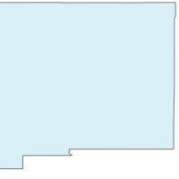

```
http://gstore.unm.edu/apps/rgis/datasets/
6ca5428a-a78c-4c82-8120-da70dc92f2cc/
services/ogc/wms?
    VERSION=1.1.1&
    SERVICE=WMS&
    REQUEST=GetMap&
    BBOX=-109,31,-102.9,37.1&
    LAYERS=tl_2010_35_state10&
    WIDTH=200&
    HEIGHT=200&
    SRS=EPSG:4326&
    FORMAT=image/jpeg&
    STYLES=
```

link

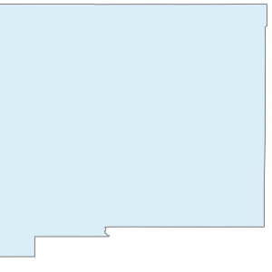

```
http://gstore.unm.edu/apps/rgis/datasets/
6ca5428a-a78c-4c82-8120-da70dc92f2cc/
services/ogc/wms?
    VERSION=1.1.1&
    SERVICE=WMS&
    REQUEST=GetMap&
    BBOX=-109,31,-102.9,37.1&
    LAYERS=tl_2010_35_state10&
    WIDTH=300&
    HEIGHT=300&
    SRS=EPSG:4326&
    TRANSPARENT=TRUE&
    FORMAT=image/png&
    STYLES=
```

link

### Integraton of WMS and KML

- The KML GroundOverlay element may be used to integrate a network accessible map image into a client
- A WMS service may be used to as the source of a KML GroundOverlay element
- KML includes parameterizations that allow for dynamic generation of WMS requests using client bounding box information
- Time-enabled WMS may be accessed through use of manually configured time parameters in WMS URLs and TimeStamp or TimeSpan KML elements

### Sample WMS-KML Integration

```xml
<?xml version="1.0" encoding="UTF-8"?>
<kml xmlns="http://www.opengis.net/kml/2.2" xmlns:gx="http://www.google.com/kml/ext/2.2"
    xmlns:kml="http://www.opengis.net/kml/2.2" xmlns:atom="http://www.w3.org/2005/Atom">
    <GroundOverlay>
        <name>RGIS Counties WMS</name>
        <Icon>
            <href>http://gstore.unm.edu/apps/rgis/datasets/107046/services/ogc/wms?
            VERSION=1.1.1&amp;SERVICE=WMS&amp;REQUEST=GetMap&amp;BBOX=-109,31,-102.9,37.1
            &amp;LAYERS=tl_2010_35_state10&amp;WIDTH=800&amp;HEIGHT=800&amp;SRS=EPSG:4326
            &amp;FORMAT=image/png&amp;STYLES=</href>
            <viewRefreshMode>onStop</viewRefreshMode>
        </Icon>
        <LatLonBox>
            <north>37.32753828398865</north>
            <south>30.86418272137246</south>
            <east>-101.3630220689848</east>
            <west>-110.6891149310152</west>
        </LatLonBox>
    </GroundOverlay>
</kml>
```

Sample KML File